# Small variant detection with short read sequencing (Partie I : Alignement)

### 2.2 Compression, tri et fusion

Pour manipuler ces fichiers, optimiser leur utilisation et l'espace disque du projet, il existe une suite d'outils appelée : [samtools](https://www.htslib.org/).  
Cherchez le module associé (`module avail` dans le Terminal) et chargez le module (`module load`)

```bash
module load samtools/1.23.1
```

Affichez l'aide de `samtools` (directement via le nom de l'outil)

```bash
samtools
```

Tout comme bwa-mem2, samtools propose plusieurs commandes.  
Pour notre projet nous allons :

- compresser les fichiers SAM en format BAM (commande `samtools view`)
- trier les fichiers d'alignement selon leurs coordonnées génomiques (commande `samtools sort`)
- fusionner les alignements appartenant au même échantillon mais provenant de différents runs, flowcells, lanes, librairies (commande `samtools merge`)

##### **a) Convertir le fichier sam (volumineux) en fichier bam (compressé) : `samtools view`.**

Affichez l'aide de `samtools view`.

```bash
samtools view
```

Le schéma de commande est :

```
Usage: samtools view [options] <in.bam>|<in.sam>|<in.cram> [region ...]
```

et les options qui nous intéressent sont :

- `-h` : Include header in (SAM) output
- `-b` : Output BAM
- `-o` : Write output to FILE [standard output]
- `-@` : Number of additional threads to use [0]

Appliquez ce schéma avec ces options pour générer un fichier bam.

```bash
samtools view -@ 4 -h -b -o Results/Alignment/milca_40995_AHYGCWDSXY_L002.bam Results/Alignment/milca_40995_AHYGCWDSXY_L002.sam
```

Explorons notre dossier de résultat : **Results/Alignment**

```bash
ls -lrth Results/Alignment/
```

```
total 2.0G
-rw-rw----+ 1 mbernard mbernard 1.8G Aug 21 13:19 milca_40995_AHYGCWDSXY_L002.sam
-rw-rw----+ 1 mbernard mbernard 265M Aug 21 13:24 milca_40995_AHYGCWDSXY_L002.bam
```

**Question**  
Que remarquez-vous ?

Le fichier bam créé n'est plus un fichier texte.  
Pour le lire vous devez utiliser de nouveau la commande `samtools view` mais sans préciser le fichier de sortie (les options `-b -o` et `-@` sont inutiles).

ℹ️ **Remarque**  
Le caractère `|` (alt gr + 6) permet d'enchainer des commandes, par exemple ici pour afficher les 10 premières lignes on enchaine `samtools view` avec la commande `head`.

```bash
samtools view -h Results/Alignment/milca_40995_AHYGCWDSXY_L002.bam | head
```

```
@SQ	SN:NC_037329.1	LN:136231102
@SQ	SN:NC_037333.1	LN:117806340
@RG	ID:40995_AHYGCWDSXY_L002	PL:ILLUMINA	PU:40995_AHYGCWDSXY_L002	LB:40995_GGTGAACC-TCCAACGC	SM:milca_40995
@PG	ID:bwa-mem2	PN:bwa-mem2	VN:2.2.1	CL:bwa-mem2 mem -t 4 -R @RG\tID:40995_AHYGCWDSXY_L002\tPL:ILLUMINA\tPU:40995_AHYGCWDSXY_L002\tLB:40995_GGTGAACC-TCCAACGC\tSM:milca_40995 -o Results/Alignment/milca_40995_AHYGCWDSXY_L002.sam data/genome/Bos_taurus_GCF_002263795.3_ARS-UCD2.0_chr2_chr6.fasta data/fa…
@PG	ID:samtools	PN:samtools	PP:bwa-mem2	VN:1.23.1	CL:samtools view -@ 4 -h -b -o Results/Alignment/milca_40995_AHYGCWDSXY_L002.bam Results/Alignment/milca_40995_AHYGCWDSXY_L002.sam
@PG	ID:samtools.1	PN:samtools	PP:samtools	VN:1.23.1	CL:samtools view -h Results/Alignment/milca_40995_AHYGCWDSXY_L002.bam
A00318:211:HYGCWDSXY:2:1608:26594:31328	81	NC_037329.1	69	0	65M23D19M1D66M	=	5286	5045	TGATCAGTGTATGACCAGCTTCGTGATCAGTGCATGATTAGTTACGTGATTAATGTATGATTAGCCACGTGATCAGTGCATGATAGCCTCGTGACCAGTGCATGATCAGTCAGGAGATCAGTGCATGATCAGCCATGGGATCAGTGCATG	FFFFFFF:FF:FFFFFFFFFFFFFFFFFFFFFFFFFFFFFFFFFFF,:FFFFFFFFFFFFFF…
A00318:211:HYGCWDSXY:2:1608:26594:31328	161	NC_037329.1	5286	18	4S32M1D99M15S	=	69	-5045	ATGGGTGCATGATCAGCCACGTGATCAGTGGAAGATTGCCAAGGGATCAGTGCATGATTAGTTACGTGATCAATGTGTGATTAGCCACGTGATTAGTTCATGATCAGCCACGTGATTAGTGCATGATCAGCCACGGGATGAGTGCATGAT	FFFFFFFFFFFFFFFFFFFFFFFFFFFFFFFF:FFFFFFFFFFFFFFFFFFFFFFFFFF:…
A00318:211:HYGCWDSXY:2:1622:13322:18709	83	NC_037329.1	315	40	150M	=	151	-314	TCACGTGATCACTGTATGATAAGCCACGTCATCAGTGCATGTGCAGTCACGTGATCAGTGTATGATCAGCCACATTATCAGTGCATGATAGCCACGTGATCAATGCATGATAGCTACATGTTCAGTGCATGCTCAGTCACCTGATCAGTG	FFFFFFFFFFFFFFFFFFFFFFFFFFFFFFFFFFFFFFFFF:FFFFFFFFFFFFFFFFFFFFFFFFFFFFF…
A00318:211:HYGCWDSXY:2:1622:13322:18709	163	NC_037329.1	151	40	150M	=	315	314	CCCAGTCACGTGATCAGTGTATGATCAGCCACGGGATCAGTGCATGCTCCACAACGTGATCAGTGCATGATCAGCCACGGGATCAGTTCATGATAGCCATGTGATCAGTGCAAGATAGCTACGTGATCAGTGCATAATCAGCCACGGAAT	FFFFFFFFFFFFFFFFFFFFFFFFFFFFFFFFFFFFFFFFFFFFFFFFFFFFFFFFF:FFFFFFFFFFF,:…
```

Vous pouvez supprimer votre fichier sam (commande `rm`).

```bash
rm Results/Alignment/milca_40995_AHYGCWDSXY_L002.sam
```

##### **b) Tri des lectures par coordonnées génomiques : `samtools sort`.**

Afficher l'aide de `samtools sort`.

```bash
samtools sort
```

Le schéma de commande est :

```
Usage: samtools sort [options...] [in.bam]
```

et les options qui nous intéressent sont :

- `-o` : Write output to FILE [standard output]
- `-@` : Number of additional threads to use [0]

Appliquez ce schéma avec ces options pour générer un fichier bam trié.

```bash
samtools sort -@ 4 -o Results/Alignment/milca_40995_AHYGCWDSXY_L002_sort.bam Results/Alignment/milca_40995_AHYGCWDSXY_L002.bam
```

Explorons notre dossier de résultat : **Results/Alignment**

```bash
ls -lrth Results/Alignment/
```

```
total 528M
-rw-rw----+ 1 mbernard mbernard 265M Aug 21 13:24 milca_40995_AHYGCWDSXY_L002.bam
-rw-rw----+ 1 mbernard mbernard 263M Aug 21 13:26 milca_40995_AHYGCWDSXY_L002_sort.bam
```

```bash
samtools view -h Results/Alignment/milca_40995_AHYGCWDSXY_L002_sort.bam | head
```

```
@HD	VN:1.6	SO:coordinate
@SQ	SN:NC_037329.1	LN:136231102
@SQ	SN:NC_037333.1	LN:117806340
@RG	ID:40995_AHYGCWDSXY_L002	PL:ILLUMINA	PU:40995_AHYGCWDSXY_L002	LB:40995_GGTGAACC-TCCAACGC	SM:milca_40995
@PG	ID:bwa-mem2	PN:bwa-mem2	VN:2.2.1	CL:bwa-mem2 mem -t 4 -R @RG\tID:40995_AHYGCWDSXY_L002\tPL:ILLUMINA\tPU:40995_AHYGCWDSXY_L002\tLB:40995_GGTGAACC-TCCAACGC\tSM:milca_40995 -o Results/Alignment/milca_40995_AHYGCWDSXY_L002.sam data/genome/Bos_taurus_GCF_002263795.3_ARS-UCD2.0_chr2_chr6.fasta data/fa…
@PG	ID:samtools	PN:samtools	PP:bwa-mem2	VN:1.23.1	CL:samtools view -@ 4 -h -b -o Results/Alignment/milca_40995_AHYGCWDSXY_L002.bam Results/Alignment/milca_40995_AHYGCWDSXY_L002.sam
@PG	ID:samtools.1	PN:samtools	PP:samtools	VN:1.23.1	CL:samtools sort -@ 4 -o Results/Alignment/milca_40995_AHYGCWDSXY_L002_sort.bam Results/Alignment/milca_40995_AHYGCWDSXY_L002.bam
@PG	ID:samtools.2	PN:samtools	PP:samtools.1	VN:1.23.1	CL:samtools view -h Results/Alignment/milca_40995_AHYGCWDSXY_L002_sort.bam
A00318:211:HYGCWDSXY:2:2658:25518:6637	99	NC_037329.1	52	0	34S116M	=	465	555	TCACATGAGCAGTGCATGATCACCCACTAGATCAGTGCACGCACAGTCACAGGATCAATGTATGATCAGCTTCGTGATCAGTGCATGATTAGTTACGTGATCAATGTATGATTAGCCAAGTAATCAGTGCATGCACAGTCACGTGATCAG	FFFFFFFFFFFFFFFFFFFFFFFFFFFFFFFFFFFFFFFFFFFFFFFFFFFFFFFF:FFFFFFFFFFFFFFF…
A00318:211:HYGCWDSXY:2:1315:13205:35133	99	NC_037329.1	52	15	65S85M	=	291	389	ATAATCAGCCACGTGATCAGTGCATGATCAACCACGTGATCAGTGCATGATCTTCCACGTAATCAGTGCATGCACAGTCACGTGATCAATGAATGATCAGCATCGTGATCAGTGCATGATTAGATACGTGATCAATGTATGAATAGCCAA	FFFFFFF:FFFFFFFFFFFFFFFFFFFFFF::FFFFFFF:FFFFFFFFFFFF,FFFF,FF:,FFFFFFFFF…
```

ℹ️ **Remarque**  
Remarquez la première ligne `@HD VN:1.6 SO:coordinate` qui indique que les alignements sont triés par coordonnées génomiques.

Inutile de conserver 2 copies des alignements. Nous pouvons supprimer le fichier bam initial (commande `rm`)

```bash
rm Results/Alignment/milca_40995_AHYGCWDSXY_L002.bam
```

##### **c) Fusion des bam correspondant au même échantillon (compressé): `samtools merge`.**

Après fusion, les read groups permettront de conserver la trace de l'origine de chaque lecture.

Pour cela récupérons d'abord les 2 autres bam triés de notre échantillon milca_40995.

```bash
cp /shared/projects/2621_eb3in1_2026/atelier_variant_correction/TP_small_variants/Results/Alignment_milca_40995/* Results/Alignment/.
```

```bash
ls -lrth Results/Alignment/
```

```
total 487M
-rw-rw----+ 1 mbernard mbernard 163M Aug 21 13:42 milca_40995_AHYGCWDSXY_L002_sort.bam
-rw-rw----+ 1 mbernard mbernard 163M Aug 21 13:42 milca_40995_AHYGCWDSXY_L003_sort.bam
-rw-rw----+ 1 mbernard mbernard 162M Aug 21 13:42 milca_40995_AHYGCWDSXY_L004_sort.bam
```

Nous allons maintenant utiliser un troisième outil de la suite samtools : `samtools merge`  
Affichez l'aide de `samtools merge`

```bash
samtools merge
```

Le schéma de commande peut être :

```
Usage: samtools merge [options] -o <out.bam> [options] <in1.bam> ... <inN.bam>
   or: samtools merge [options] <out.bam> <in1.bam> ... <inN.bam>
```

et les options qui nous intéressent sont :

- `-o` : Specify output file
- `-@` : Number of additional threads to use [0]

Appliquez ce schéma avec ces options pour fusionner les 3 bam de notre échantillon `milca_40995`.

```bash
samtools merge -@ 4 \
    -o Results/Alignment/milca_40995.bam \
    Results/Alignment/milca_40995_AHYGCWDSXY_L002_sort.bam \
    Results/Alignment/milca_40995_AHYGCWDSXY_L003_sort.bam \
    Results/Alignment/milca_40995_AHYGCWDSXY_L004_sort.bam
```

Explorons notre dossier de résultat : Results/Alignment

```bash
ls -lrth Results/Alignment
```

```
total 913M
-rw-rw----+ 1 mbernard mbernard 163M Aug 21 13:42 milca_40995_AHYGCWDSXY_L002_sort.bam
-rw-rw----+ 1 mbernard mbernard 163M Aug 21 13:42 milca_40995_AHYGCWDSXY_L003_sort.bam
-rw-rw----+ 1 mbernard mbernard 162M Aug 21 13:42 milca_40995_AHYGCWDSXY_L004_sort.bam
-rw-rw----+ 1 mbernard mbernard 427M Aug 21 13:45 milca_40995.bam
```

```bash
samtools view -h Results/Alignment/milca_40995.bam | head
```

```
@HD	VN:1.6	SO:coordinate
@SQ	SN:NC_037329.1	LN:136231102
@SQ	SN:NC_037333.1	LN:117806340
@RG	ID:milca_40995_AHYGCWDSXY_L002	PL:ILLUMINA	PU:milca_40995_AHYGCWDSXY_L002	LB:milca_40995_GGTGAACC-TCCAACGC	SM:milca_40995
@RG	ID:milca_40995_AHYGCWDSXY_L003	PL:ILLUMINA	PU:milca_40995_AHYGCWDSXY_L003	LB:milca_40995_GGTGAACC-TCCAACGC	SM:milca_40995
@RG	ID:milca_40995_AHYGCWDSXY_L004	PL:ILLUMINA	PU:milca_40995_AHYGCWDSXY_L004	LB:milca_40995_GGTGAACC-TCCAACGC	SM:milca_40995
@PG	ID:bwa-mem2	PN:bwa-mem2	VN:2.2.1	CL:bwa-mem2 mem -t 4 -R @RG\tID:milca_40995_AHYGCWDSXY_L002\tPL:ILLUMINA\tPU:milca_40995_AHYGCWDSXY_L002\tLB:milca_40995_GGTGAACC-TCCAACGC\tSM:milca_40995 /shared/projects/2621_eb3in1_2026/atelier_variant/TP_small_variants/data/genome/Bos_taurus_GCF_002263795.3_A…
@PG	ID:samtools	PN:samtools	PP:bwa-mem2	VN:1.23.1	CL:samtools view -@ 4 -h -b -o /shared/projects/2621_eb3in1_2026/atelier_variant_correction/TP_small_variants/Results/Alignment/milca_40995_AHYGCWDSXY_L002.bam /shared/projects/2621_eb3in1_2026/atelier_variant_correction/TP_small_variants/Results/Ali…
@PG	ID:samtools.1	PN:samtools	PP:samtools	VN:1.23.1	CL:samtools sort -@ 4 -o /shared/projects/2621_eb3in1_2026/atelier_variant_correction/TP_small_variants/Results/Alignment/milca_40995_AHYGCWDSXY_L002_sort.bam /shared/projects/2621_eb3in1_2026/atelier_variant_correction/TP_small_variants/Results/Al…
@PG	ID:bwa-mem2-3D812485	PN:bwa-mem2	VN:2.2.1	CL:bwa-mem2 mem -t 4 -R @RG\tID:milca_40995_AHYGCWDSXY_L003\tPL:ILLUMINA\tPU:milca_40995_AHYGCWDSXY_L003\tLB:milca_40995_GGTGAACC-TCCAACGC\tSM:milca_40995 /shared/projects/2621_eb3in1_2026/atelier_variant/TP_small_variants/data/genome/Bos_taurus_GCF_0022…
```

ℹ️ **Remarque**  
Remarquez l'ajout des lignes correspondant à chaque read group.  
Par ailleurs l'ensemble des lignes de commande qui ont permis la création de ce fichier sont tracées par les lignes `@PG`

Nous pouvons supprimer les fichiers triés individuels

```bash
rm Results/Alignment/*_sort.bam
```

ℹ️ **Remarque**  
Le caractère `*` signifie tout, autrement dit dans la commande précédente tous les fichiers qui commencent par `Results/Alignment/` et qui terminent par `_sort.bam`.

⚠️ Warning ⚠️  
À manipuler avec précaution si vous mettez un espace entre `*` et `_sort.bam` vous supprimez tout le contenu du dossier `Results/Alignment/`.

```bash
ls -lrth Results/Alignment
```

```
total 427M
-rw-rw----+ 1 mbernard mbernard 427M Aug 21 13:45 milca_40995.bam
```

## III - Processing post alignement

Rappel du workflow

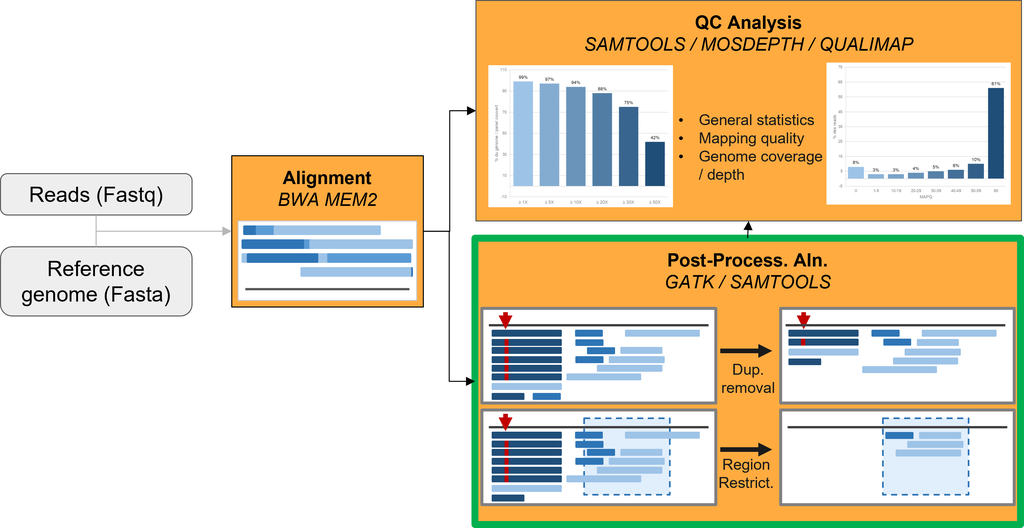

### 1. Marquage des duplicats de PCR

Identifier les **reads provenant d'une même molécule** issus de :

- PCR duplicates : amplification PCR durant la préparation de la librairie
- Optical duplicates : Cluster Illumina identifié comme deux clusters

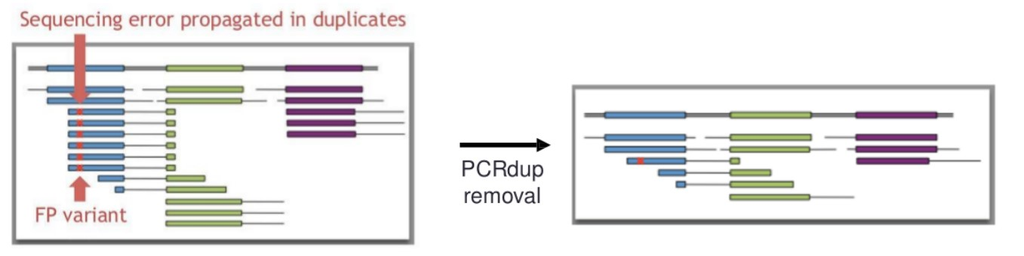

Plusieurs modes d'analyses :

- Garder les duplicats : probabilité importante de confondre les duplicats avec des fragments biologiques issus du même locus
- Marquer les duplicats mais les conserver dans le fichier BAM. De nombreux outils prennent en compte cette information (samtools, GATK...)
- Supprimer les duplicats du fichier BAM, peut être nécessaire selon l'outil ou les analyses que l'on souhaite faire ensuite.

L'identification des duplicats se fait grâce à l'outil **MarkDuplicates** de la suite **PicardTools** intégrée à la suite [**GATK**](https://gatk.broadinstitute.org/hc/en-us).  
Identifiez le module associé à GATK (`module avail` dans le Terminal) puis chargez-le (`module load`).

```bash
module load gatk4/4.6.1.0
```

GATK est une suite d'outils tournée vers l'identification de petits variants. Elle inclut de très nombreux outils.  
Pour afficher la liste des outils inclus, utilisez `gatk --help` dans le Terminal, ou la documentation en ligne via [le listing des outils](https://gatk.broadinstitute.org/hc/en-us/articles/30331989211419--Tool-Documentation-Index).

Pour afficher l'aide d'un outil en particulier, utilisez `gatk TOOL_NAME --help` ou la page dédiée dans la documentation en ligne.

L'aide de l'outil `MarkDuplicates` est relativement longue, nous vous conseillons de consulter [la documentation en ligne](https://gatk.broadinstitute.org/hc/en-us/articles/30332022936475-MarkDuplicates-Picard).

GATK est développé en java. La syntaxe originale de ce type d'outils est :

```
java -jar gatk.jar TOOL_NAME -Xmx8G OPTION=VALEUR OPTION=VALEUR ...
```

`-Xmx8G`, permet de préciser la mémoire allouée à l'outil.

Avec GATK, il est possible d'utiliser une syntaxe plus classique.

```
gatk TOOL_NAME --java-options '-Xmx8G' --OPTION VALEUR --OPTION VALEUR
```

Pour MarkDuplicates, le schéma de commande est :

```
Usage: gatk MarkDuplicates --java-options '-Xmx8G' \
     --INPUT input.bam \
     --OUTPUT marked_duplicates.bam \
     --METRICS_FILE marked_dup_metrics.txt
```

et les options qui nous intéressent sont:

- `--VALIDATION_STRINGENCY SILENT` : qui permet d'améliorer les performances.
- `--CREATE_INDEX` : qui permet la création de l'index associé au fichier bam de sortie.

Appliquez ce schéma avec ces options pour générer un bam dans lequel les duplicats sont marqués.

```bash
# Lancement de l'outil
gatk MarkDuplicates --java-options '-Xmx8G' \
    --INPUT Results/Alignment/milca_40995.bam  \
    --OUTPUT Results/Alignment/milca_40995_md.bam \
    --METRICS_FILE Results/Alignment/milca_40995_metrics_md.txt \
    --VALIDATION_STRINGENCY SILENT \
    --CREATE_INDEX
```

Affichons le contenu de notre dossier : **Results/Alignment**

```bash
ls -lrth Results/Alignment
```

```
total 933M
-rw-rw----+ 1 mbernard mbernard 427M Aug 21 13:45 milca_40995.bam
-rw-rw----+ 1 mbernard mbernard 506M Aug 21 13:56 milca_40995_md.bam
-rw-rw----+ 1 mbernard mbernard 620K Aug 21 13:56 milca_40995_md.bai
-rw-rw----+ 1 mbernard mbernard 4.3K Aug 21 13:56 milca_40995_metrics_md.txt
```

MarkDuplicates produit 3 nouveaux fichiers:

- un nouveau fichier bam accompagné de son index (.bai)
- un fichier texte qui décrit les résultats d'analyse

Le fichier metrics_md.txt est un fichier texte assez long. Nous pouvons :

- le lire dans le Terminal avec les commandes `more`, `less` (ou `cat`)
- afficher uniquement le début du fichier (15 premières lignes) avec `head -n 15`.

```bash
head -n 15 Results/Alignment/milca_40995_metrics_md.txt
```

```
## htsjdk.samtools.metrics.StringHeader
# MarkDuplicates --INPUT Results/Alignment/milca_40995.bam --OUTPUT Results/Alignment/milca_40995_md.bam --METRICS_FILE Results/Alignment/milca_40995_metrics_md.txt --VALIDATION_STRINGENCY SILENT --CREATE_INDEX true --MAX_SEQUENCES_FOR_DISK_READ_ENDS_MAP 50000 --MAX_FILE_HANDLES_FOR_READ_ENDS_MAP 80…
## htsjdk.samtools.metrics.StringHeader
# Started on: Fri Aug 21 13:55:10 CEST 2026

## METRICS CLASS	picard.sam.DuplicationMetrics
LIBRARY	UNPAIRED_READS_EXAMINED	READ_PAIRS_EXAMINED	SECONDARY_OR_SUPPLEMENTARY_RDS	UNMAPPED_READS	UNPAIRED_READ_DUPLICATES	READ_PAIR_DUPLICATES	READ_PAIR_OPTICAL_DUPLICATES	PERCENT_DUPLICATION	ESTIMATED_LIBRARY_SIZE
milca_40995_GGTGAACC-TCCAACGC	0	5913440	51855	83980	0	909950	77971	0.153878	18469612

## HISTOGRAM	java.lang.Double
BIN	CoverageMult	all_sets	optical_sets	non_optical_sets
1.0	1.011338	4278431	0	4331861
2.0	1.745594	612478	72454	577016
3.0	2.278682	88036	2472	74466
4.0	2.665717	15137	161	11853
```

Pour récupérer uniquement le tableau résumé et notamment le % de duplicats marqués, nous pouvons faire une recherche de mots avec `grep` et afficher la ligne qui suit (option `-A`).

```bash
grep -A 1 "LIBRARY" Results/Alignment/milca_40995_metrics_md.txt
```

```
LIBRARY	UNPAIRED_READS_EXAMINED	READ_PAIRS_EXAMINED	SECONDARY_OR_SUPPLEMENTARY_RDS	UNMAPPED_READS	UNPAIRED_READ_DUPLICATES	READ_PAIR_DUPLICATES	READ_PAIR_OPTICAL_DUPLICATES	PERCENT_DUPLICATION	ESTIMATED_LIBRARY_SIZE
milca_40995_GGTGAACC-TCCAACGC	0	5913440	51855	83980	0	909950	77971	0.153878	18469612
```

**Question**

- Quelle est la proportion de reads dupliqués dans notre jeu de données ?
- Pourquoi n'a-t-on qu'une seule valeur de taux de duplication?

Pour lire le fichier `40995_md.bam`, nous devons comme précédemment utiliser la commande `samtools view` et pour afficher uniquement les 10 premières lignes on la fait suivre par la commande `head`.

```bash
samtools view Results/Alignment/milca_40995_md.bam | head
```

```
A00318:211:HYGCWDSXY:3:2266:19669:8406	1137	NC_037329.1	43	11	8M1D142M	=	43	0	TGTATTCAGTGCACGCACAGTCACGTGATCAATGTATGATCAGCTTCGTGATCAGTGCATGATTAGTTACGTGATCAATGTATGATTAGCCAAGTAATCAGTGTATGCACAGTCACGTGATCAGTGTATGATCAGCCACGTGACCAGTGC	FFFF,FFFFFFFFFFFFFFFFFFFFFFFFFFFFFFFFFFFFFFFFFFFFFFFFFFFFFFFFFFFF::FFFF…
A00318:211:HYGCWDSXY:3:2266:19669:8406	1201	NC_037329.1	43	11	8M1D142M	=	43	0	TGTATTCAGTGCACGCACAGTCACGTGATCAATGTATGATCAGCTTCGTGATCAGTGCATGATTAGTTACGTGATCAATGTATGATTAGCCAAGTAATCAGTGTATGCACAGTCACGTGATCAGTGTATGATCAGCCACGTGACCAGTGC	FFFF,FFFFFFFFFFFFFFFFFFFFFFFFFFFFFFFFFFFFFFFFFFFFFFFFFFFFFFFFFFFF::FFFF…
A00318:211:HYGCWDSXY:3:2266:19931:8547	113	NC_037329.1	43	11	8M1D142M	=	43	0	TGTATTCAGTGCACGCACAGTCACGTGATCAATGTATGATCAGCTTCGTGATCAGTGCATGATTAGTTACGTGATCAATGTATGATTAGCCAAGTAATCAGTGTATGCACAGTCACGTGATCAGTGTATGATCAGCCACGTGACCAGTGC	FFFFFFFFFFFFFFFFFFFFFFFFFFFFFFFFFFFFFFFFFFFFFFFFFFFFFFFFFFFFFFFFFFFFFFFF…
A00318:211:HYGCWDSXY:3:2266:19931:8547	177	NC_037329.1	43	11	8M1D142M	=	43	0	TGTATTCAGTGCACGCACAGTCACGTGATCAATGTATGATCAGCTTCGTGATCAGTGCATGATTAGTTACGTGATCAATGTATGATTAGCCAAGTAATCAGTGTATGCACAGTCACGTGATCAGTGTATGATCAGCCACGTGACCAGTGC	FFFFFFFFFFFFFFFFFFFFFFFFFFFFFFFFFFFFFFFFFFFFFFFFFFFFFFFFFFFFFFFFFFFFFFFF…
A00318:211:HYGCWDSXY:2:1541:15646:10488	65	NC_037329.1	61	2	110S40M	=	61	0	TGATCAGTGTATGATATCCAGTGCATGATAGCCACGTGCCCAGTACAGGCTTAATCAGTGCAATATCATCCACGTGATCAGTGCAAGCACAGTCAAGTGATCAGTGCATCCAGTCACGTGATCAATGTATGATCAGCTTCGTGATCAGAG	FF:FFFFFFFFFFFFFFFFFFFFFFFFFFFFFFFFFFFFFFFFFFFFFFFFFFFFFFFFFFFFFFFFFFFFFFF…
A00318:211:HYGCWDSXY:2:1541:15646:10488	129	NC_037329.1	61	2	110S40M	=	61	0	TGATCAGTGTATGATATCCAGTGCATGATAGCCACGTGCCCAGTACAGGCTTAATCAGTGCAATATCATCCACGTGATCAGTGCAAGCACAGTCAAGTGATCAGTGCATCCAGTCACGTGATCAATGTATGATCAGCTTCGTGATCAGAG	FF:FFFFFFFFFFFFFFFFFFFFFFFFFFFFFFFFFFFFFFFFFFFFFFFFFFFFFFFFFFFFFFFFFFFFFF…
A00318:211:HYGCWDSXY:2:2314:16043:20666	1089	NC_037329.1	61	2	110S40M	=	61	0	TGATCAGTGTATGATATCCAGTGCATGATAGCCACGTGCCCAGTACAGGCTTAATCAGTGCAATATCATCCACGTGATCAGTGCAAGCACAGTCAAGTGATCAGTGCATCCAGTCACGTGATCAATGTATGATCAGCTTCGTGATCAGAG	FFFFFFFFFFFFFFFFFFFFFFFFFFFFFFFFFFFFFFFFFFFFFFFFFF:FFFFFFFFFFFFFFFFFFFFF…
A00318:211:HYGCWDSXY:2:2314:16043:20666	1153	NC_037329.1	61	2	110S40M	=	61	0	TGATCAGTGTATGATATCCAGTGCATGATAGCCACGTGCCCAGTACAGGCTTAATCAGTGCAATATCATCCACGTGATCAGTGCAAGCACAGTCAAGTGATCAGTGCATCCAGTCACGTGATCAATGTATGATCAGCTTCGTGATCAGAG	FFFFFFFFFFFFFFFFFFFFFFFFFFFFFFFFFFFFFFFFFFFFFFFFFF:FFFFFFFFFFFFFFFFFFFFF…
A00318:211:HYGCWDSXY:3:1160:22444:9987	2113	NC_037329.1	61	0	107H43M	=	17624	17564	CAGTCACGTGATCAATGTATGATCAGCTTCGTGATCAGTGTAT	FFFFFFFFFFFFF:F,:FFFFF:F:FFF,FFFFFF:FFFF:FF	SA:Z:NC_037329.1,17624,+,4M1D44M8D34M68S,0,13;	MC:Z:4M1D44M8D34M68H	MD:Z:40C2	PG:Z:MarkDuplicates	RG:Z:milca_40995_AHYGCWDSXY_L00…
A00318:211:HYGCWDSXY:3:1160:22444:9987	2177	NC_037329.1	61	0	107H43M	=	17624	17564	CAGTCACGTGATCAATGTATGATCAGCTTCGTGATCAGTGTAT	FFFFFFFFFFFFF:F,:FFFFF:F:FFF,FFFFFF:FFFF:FF	SA:Z:NC_037329.1,17624,+,4M1D44M8D34M68S,0,13;	MC:Z:4M1D44M8D34M68H	MD:Z:40C2	PG:Z:MarkDuplicates	RG:Z:milca_40995_AHYGCWDSXY_L00…
```

**Question**  
Que signifie le flag 1137?

Nous n'avons plus besoin du fichier précédant l'étape de MarkDuplicates. Supprimez-le avec la commande `rm`.

```bash
rm Results/Alignment/milca_40995.bam
```

### 2. Filtres sur les alignements (optionnel)

Il peut être intéressant / nécessaire de filtrer les alignements avant de poursuivre. Par exemple :

- Conserver les lectures avec une qualité de mapping (MAPQ) minimale.

```
samtools view -bh -q 30 -o output.bam input.bam
```

- Supprimer les lectures non mappées, les alignements secondaires ou supplémentaires.

```
samtools view -bh -F 4 -o output.bam input.bam
samtools view -bh -F 256 -o output.bam input.bam
samtools view -bh -F 2048 -o output.bam input.bam
```

- Conserver les alignements chevauchant des régions d'intérêt (capture / QTL / ...).  
  Pour cela, il est nécessaire de définir les régions grâce à un fichier tabulé `.bed`) : chr, start, stop

```
module load bedtools/2.31.1
bedtools intersect \
    -a input.bam \
    -b regions.bed \
    > output.bam
```

- Filtrer en fonction du nombre de mismatchs, de la taille d'insert, de paires mappées sur des chromosomes différents, ...

Dans notre cas, nous serons vigilants à la qualité de l'alignement mais ce paramètre sera directement pris en compte par les prochains outils.

## IV - Contrôles qualité

Rappel du workflow

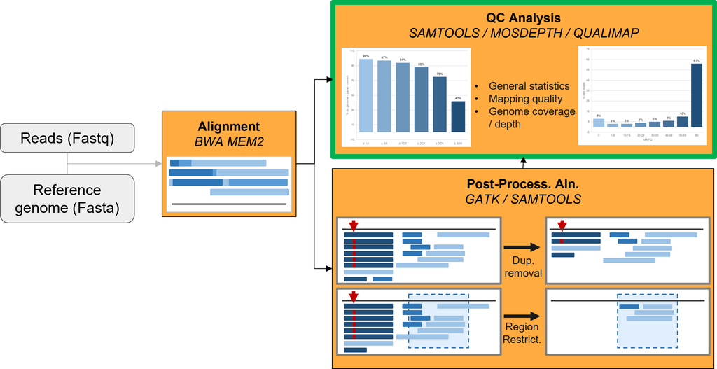

**Question**  
Quelles informations regarder une fois le mapping effectué ?

- Pourcentage total de reads alignés
- Pourcentage de reads pairés “proprement”
- Pourcentage de reads dupliqués
- Distribution des qualités d'alignement
- Distribution de la profondeur de couverture le long du génome.

Avec quels outils ?

- samtools flagstat
- mosdepth
- qualimap

Nous allons explorer ces différents outils sur nos alignements avec les duplicats marqués.  
Si sur vos données vous appliquez des filtres, il peut être utile de produire ces contrôles avant et après filtre.

Commençons par créer un nouveau dossier de résultats.

```bash
mkdir -p Results/Alignment_stat
```

### 1. Métriques quantitatives avec `samtools flagstat`

Cet outil de la suite `samtools` propose une description résumée des alignements produits.

Afficher l'aide de `samtools flagstat`.

```bash
samtools flagstat
```

Le schéma de commande est :

```
Usage: samtools flagstat [options] <in.bam>
```

et la seule option qui nous intéresse est :

- `-@` : Number of additional threads to use [0]

Appliquez ce schéma avec cette option pour générer les statistiques d'alignement résumées de votre fichier bam trié et avec les duplicats marqués.

ℹ️ **Remarque**

- Pour récupérer le texte qui s'affiche à l'écran dans un fichier terminez votre commande par `> mon_fichier`
- Utilisez toujours des noms de fichiers plus pertinents que `mon_fichier` 😉 !
- Rappel, pour lire un fichier texte vous pouvez utiliser les commandes `cat`, `more` ou `less` suivies du chemin vers votre fichier

```bash
samtools flagstat -@ 4 Results/Alignment/milca_40995_md.bam > Results/Alignment_stat/milca_40995_md_flagstat.txt
cat Results/Alignment_stat/milca_40995_md_flagstat.txt
```

[output not shown]

`samtools flagstat` interprète la 2e colonne du fichier bam (le `flag`) pour retranscrire le type d'alignement et les quantifier.

**Question**

- À quoi peuvent bien correspondre les alignements primaires, secondaires et supplémentaires ?
- Quelles peuvent être les propriétés des lectures proprement pairées ?

### 2. Analyse de la couverture/profondeur avec `mosdepth`

La couverture et la profondeur sont deux notions importantes :

- la couverture représente le nombre de bases couvertes au moins une fois.
- la profondeur représente le nombre de lectures couvrant une base.

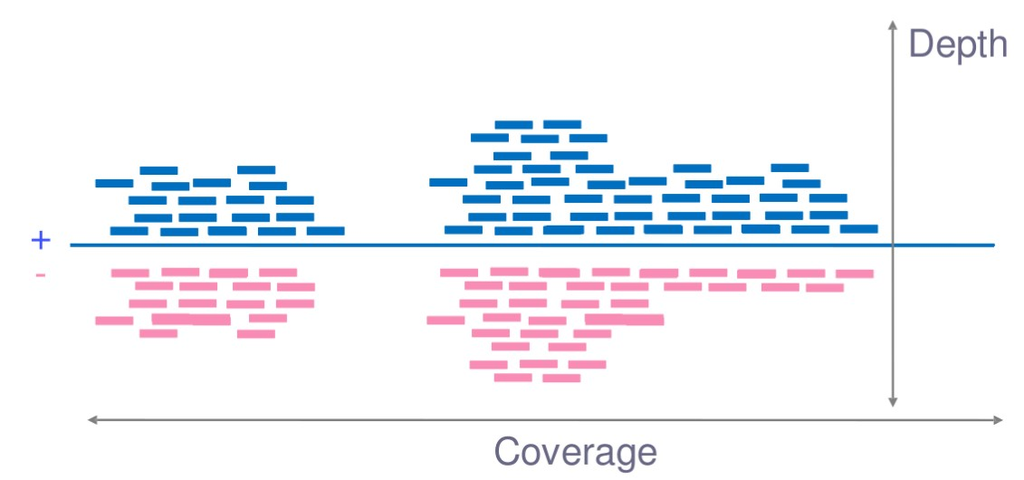

Elles permettent de contrôler :

- si j'ai suffisamment de lectures sur une position donnée ?
- si cette profondeur de couverture est homogène sur tout le génome/les régions sélectionné(es) ?

Pour calculer ces métriques nous utilisons un nouvel outil, [`mosdepth`](https://github.com/brentp/mosdepth).

Après identification du module correspondant (`module avail` dans le Terminal), chargez-le, puis affichez l'aide.

```bash
module load mosdepth/0.2.6
mosdepth -h
```

Le schéma de commande est :

```
Usage:  mosdepth [options] <prefix> <BAM-or-CRAM>
```

et les options qui nous intéressent sont :

- `--fast-mode` : fast mode
- `--threads` : number of threads

D'autres options vous permettent de travailler à l'échelle de régions (de taille fixe ou prédéfinies par un fichier `.bed`): `--by`, `--thresholds` ou `--use-median`.

Appliquez ce schéma avec ces options pour générer les statistiques d'alignement de votre fichier bam trié et avec les duplicats marqués.

```bash
mosdepth --fast-mode --threads 4 Results/Alignment_stat/milca_40995_md Results/Alignment/milca_40995_md.bam
```

Vérifions le contenu de notre répertoire de résultats

```bash
ls -lrth Results/Alignment_stat/
```

```
total 56M
-rw-rw----+ 1 mbernard mbernard  528 Aug 21 14:05 milca_40995_md_flagstat.txt
-rw-rw----+ 1 mbernard mbernard  56M Aug 21 14:10 milca_40995_md.per-base.bed.gz
-rw-rw----+ 1 mbernard mbernard 3.5K Aug 21 14:10 milca_40995_md.per-base.bed.gz.csi
-rw-rw----+ 1 mbernard mbernard  160 Aug 21 14:10 milca_40995_md.mosdepth.summary.txt
-rw-rw----+ 1 mbernard mbernard  12K Aug 21 14:10 milca_40995_md.mosdepth.global.dist.txt
```

Mosdepth produit 3 fichiers de sortie au format texte (et un index):

- milca_40995_md.per-base.bed.gz et son index milca_40995_md.per-base.bed.gz.csi  
  Ce fichier `bed.gz` est un fichier texte compressé. Pour le lire vous pouvez utiliser la commande `zcat` suivi de `less` (ou `more` ou `head` pour ne voir que le début)
- milca_40995_md.mosdepth.summary.txt
- milca_40995_md.mosdepth.global.dist.txt

Explorons-les un à un.

- **per-base.bed.gz**

```bash
zcat Results/Alignment_stat/milca_40995_md.per-base.bed.gz | head
```

```
NC_037329.1	0	42	0
NC_037329.1	42	60	2
NC_037329.1	60	68	16
NC_037329.1	68	69	19
NC_037329.1	69	75	22
NC_037329.1	75	81	23
NC_037329.1	81	82	24
NC_037329.1	82	89	25
NC_037329.1	89	90	27
NC_037329.1	90	95	37
```

**Question**  
C'est un fichier `bed`, d'après vous à quoi correspond chaque colonne ?

- **mosdepth.summary.txt**

```bash
cat Results/Alignment_stat/milca_40995_md.mosdepth.summary.txt
```

```
chrom	length	bases	mean	min	max
NC_037329.1	136231102	1479453498	10.86	0	2763
NC_037333.1	117806340	14115684	0.12	0	4077
total	254037442	1493569182	5.88	0	4077
```

**Question**  
D'après vous, que signifie la colonne *bases*?

- **global.dist.txt**

Regardez le début (`head`) et la fin (`tail`).

```bash
head -n 5 Results/Alignment_stat/milca_40995_md.mosdepth.global.dist.txt
```

```
NC_037329.1	370	0.00
NC_037329.1	369	0.00
NC_037329.1	368	0.00
NC_037329.1	367	0.00
NC_037329.1	366	0.00
```

```bash
tail -n 5 Results/Alignment_stat/milca_40995_md.mosdepth.global.dist.txt
```

```
total	4	0.52
total	3	0.52
total	2	0.55
total	1	0.55
total	0	1.00
```

**Question**  
Comment interpréter les lignes de ce fichier ?

💡 **Astuce**  
Le fichier `.mosdepth.global.dist.txt` indique la proportion du génome couverte a minima par chaque niveau de profondeur.  
Pour identifier la proportion de chaque chromosome (ou région d'intérêt si vous utilisez l'option `--by`) couverte au moins 1 (ou 10 ou 20) fois, utilisez `awk`:

```
# sélection des lignes où la 2e colonne ($2) est égale à 1 (==1)
awk '$2==1' Results/Alignment_stat/milca_40995_md.mosdepth.global.dist.txt
```

```bash
awk '$2==1' Results/Alignment_stat/milca_40995_md.mosdepth.global.dist.txt
```

```
NC_037329.1	1	0.99
NC_037333.1	1	0.04
total	1	0.55
```

```bash
awk '$2==10' Results/Alignment_stat/milca_40995_md.mosdepth.global.dist.txt
```

```
NC_037329.1	10	0.61
NC_037333.1	10	0.00
total	10	0.33
```

### 3. Analyse qualitative globale avec `qualimap`

[Qualimap](http://qualimap.conesalab.org/doc_html/analysis.html) est un autre outil relativement complet dédié à la description de résultats d'alignement  
Il produit un rapport HTML avec notamment des sorties graphiques, permettant une interprétation plus rapide.  
Pour pouvoir utiliser ce nouvel outil vous devez identifier (`module avail` dans le Terminal) puis charger le module correspondant (`module load`).

```bash
module load qualimap/2.3
```

Afficher l'aide de `qualimap`

```bash
qualimap -h
```

Noter la mention d'un argument spécial : `--java-mem-size`  
La commande qui nous intéresse ici est `qualimap bamqc`.  
Afficher l'aide de `qualimap bamqc`.

```bash
qualimap bamqc
```

Le schéma de commande est :

```
Usage: qualimap bamqc -bam <arg> [-c] [-cl <arg>] [-dl <arg>] [-gd <arg>] [-gff
       <arg>] [-hm <arg>] [-ip] [-nr <arg>] [-nt <arg>] [-nw <arg>] [-oc <arg>]
       [-os] [-outdir <arg>] [-outfile <arg>] [-outformat <arg>] [-p <arg>]
       [-sd] [-sdmode <arg>]
```

et les options qui nous intéressent sont :

- `-bam` : Input mapping file in BAM format
- `-outdir` : Output folder for HTML report and raw data.
- `-nt` : Number of threads (default is 4)

Par ailleurs, qualimap est un programme java, nous pouvons jouer avec la mémoire allouée à la commande grâce à l'option `--java-mem-size=4G`

Appliquez ce schéma avec ces options pour générer les statistiques d'alignement de votre fichier bam trié et avec les duplicats marqués.  
Le résultat généré est un rapport HTML. Il vous faudra le télécharger pour le visualiser.

```bash
qualimap bamqc -nt 4 -bam Results/Alignment/milca_40995_md.bam -outdir Results/Alignment_stat/milca_40995_md_qualimap_report --java-mem-size=4G
```

Explorons notre dossier de résultats

```bash
ls -lrth Results/Alignment_stat/*
```

```
-rw-rw----+ 1 mbernard mbernard  528 Aug 21 14:05 Results/Alignment_stat/milca_40995_md_flagstat.txt
-rw-rw----+ 1 mbernard mbernard  56M Aug 21 14:10 Results/Alignment_stat/milca_40995_md.per-base.bed.gz
-rw-rw----+ 1 mbernard mbernard 3.5K Aug 21 14:10 Results/Alignment_stat/milca_40995_md.per-base.bed.gz.csi
-rw-rw----+ 1 mbernard mbernard  160 Aug 21 14:10 Results/Alignment_stat/milca_40995_md.mosdepth.summary.txt
-rw-rw----+ 1 mbernard mbernard  12K Aug 21 14:10 Results/Alignment_stat/milca_40995_md.mosdepth.global.dist.txt

Results/Alignment_stat/milca_40995_md_qualimap_report:
total 23K
-rw-rw----+ 1 mbernard mbernard 5.1K Aug 21 14:20 genome_results.txt
-rw-rw----+ 1 mbernard mbernard  18K Aug 21 14:20 qualimapReport.html
drwxrwx---+ 2 mbernard mbernard   13 Aug 21 14:20 images_qualimapReport
drwxrwx---+ 2 mbernard mbernard   23 Aug 21 14:20 css
drwxrwx---+ 2 mbernard mbernard   12 Aug 21 14:20 raw_data_qualimapReport
```

Le résultat de qualimap est un rapport HTML.

⚠️**Warning**  
Ce fichier pour s'afficher correctement doit toujours être accompagné des dossiers `images_qualimapReport`, `css` et `raw_data_qualimapReport`.  
Il vous faut télécharger l'ensemble de ces résultats pour les visualiser.

Vous pouvez soit :

- utiliser FileZilla pour télécharger l'ensemble du dossier `Results/Alignment_stat/milca_40995_md_qualimap_report`.
- créer une archive de ce même dossier et la télécharger directement via l'interface Jupyter.

Pour créer une archive zip, utilisons la commande `zip` :

```
Usage : zip -r ARCHIVE_NAME.zip File1 File2 FolderN...
```

l'option `-r` permet d'identifier les fichiers de manière récursive dans l'arborescence du dossier.

```bash
zip -r milca_40995_md_qualimap_report.zip Results/Alignment_stat/milca_40995_md_qualimap_report
```

**Question**  
Que pensez-vous des profils de profondeur/couverture et de mapping quality?

Nous avons contrôlé les alignements d'un seul échantillon et nous en avons 3 autres.

L'avantage de qualimap c'est qu'il propose un outil d'agrégation des rapports bamqc : `qualimap multi-bamqc`

Commençons par récupérer les contrôles qualité des autres échantillons.

```bash
cp -r /shared/projects/2621_eb3in1_2026/atelier_variant_correction/TP_small_variants/Results/Alignment_stat/* Results/Alignment_stat/.
```

Afficher l'aide de `qualimap multi-bamqc`.

```bash
qualimap multi-bamqc
```

Le schéma de commande est :

```
Usage : qualimap multi-bamqc [-c] -d <arg> [-gff <arg>] [-hm <arg>] [-nr <arg>]
       [-nw <arg>] [-outdir <arg>] [-outfile <arg>] [-outformat <arg>] [-p
       <arg>] [-r]
```

et les options qui nous intéressent sont :

- `-d` : File describing the input data. Format of the file is a 2-column tab-delimited table.
  - Column 1: sample name
  - Column 2: either path to the BAM QC result
- `-outdir` : Output folder for HTML report and raw data.

Par ailleurs, qualimap est un programme java, nous pouvons jouer avec la mémoire allouée à la commande grâce à l'option `--java-mem-size=4G`

Nous devons donc d'abord créer un fichier tabulé qui indique la correspondance entre chaque échantillon et chaque rapport qualimap.  
Créez un fichier `Results/Alignment_stat/qualimap_report_path.tsv` à la main ou utilisez le code suivant.

```bash
for report in `ls Results/Alignment_stat/ | grep qualimap`
do
sample=`basename $report | sed 's/_md_qualimap_report//'`
echo -e $sample"\tResults/Alignment_stat/"$report >> Results/Alignment_stat/qualimap_report_path.tsv
done
```

```bash
cat Results/Alignment_stat/qualimap_report_path.tsv
```

```
control_41011	Results/Alignment_stat/control_41011_md_qualimap_report
control_41012	Results/Alignment_stat/control_41012_md_qualimap_report
milca_40995	Results/Alignment_stat/milca_40995_md_qualimap_report
milca_40998	Results/Alignment_stat/milca_40998_md_qualimap_report
```

Appliquez le schéma de commande de qualimap avec les options listées précédemment (`-d`, `-outdir`) pour générer un rapport combiné des rapports qualimap.  
Le résultat généré est un rapport HTML. Il vous faudra le télécharger pour le visualiser.

```bash
qualimap multi-bamqc -d Results/Alignment_stat/qualimap_report_path.tsv -outdir Results/Alignment_stat/multi_qualimap_reports
```

Explorons le contenu de notre dossier **Results/Alignment_stat/**

```bash
ls -lth  Results/Alignment_stat/
```

```
total 243M
drwxrwx---+ 5 mbernard mbernard    4 Aug 21 14:29 multi_qualimap_reports
-rw-rw----+ 1 mbernard mbernard  272 Aug 21 14:29 qualimap_report_path.tsv
drwxr-x---+ 5 mbernard mbernard    5 Aug 21 14:27 milca_40998_md_qualimap_report
-rw-rw----+ 1 mbernard mbernard  529 Aug 21 14:27 milca_40998_md_flagstat.txt
-rw-rw----+ 1 mbernard mbernard  16K Aug 21 14:27 milca_40998_md.per-base.bed.gz.csi
-rw-rw----+ 1 mbernard mbernard  72M Aug 21 14:27 milca_40998_md.per-base.bed.gz
-rw-rw----+ 1 mbernard mbernard  160 Aug 21 14:27 milca_40998_md.mosdepth.summary.txt
-rw-rw----+ 1 mbernard mbernard  13K Aug 21 14:27 milca_40998_md.mosdepth.global.dist.txt
-rw-rw----+ 1 mbernard mbernard  528 Aug 21 14:27 milca_40995_md_flagstat.txt
-rw-rw----+ 1 mbernard mbernard 3.5K Aug 21 14:27 milca_40995_md.per-base.bed.gz.csi
-rw-rw----+ 1 mbernard mbernard  56M Aug 21 14:27 milca_40995_md.per-base.bed.gz
-rw-rw----+ 1 mbernard mbernard  160 Aug 21 14:27 milca_40995_md.mosdepth.summary.txt
-rw-rw----+ 1 mbernard mbernard  12K Aug 21 14:27 milca_40995_md.mosdepth.global.dist.txt
drwxr-x---+ 5 mbernard mbernard    5 Aug 21 14:27 control_41012_md_qualimap_report
-rw-rw----+ 1 mbernard mbernard  528 Aug 21 14:27 control_41012_md_flagstat.txt
-rw-rw----+ 1 mbernard mbernard 9.5K Aug 21 14:27 control_41012_md.per-base.bed.gz.csi
-rw-rw----+ 1 mbernard mbernard  64M Aug 21 14:27 control_41012_md.per-base.bed.gz
-rw-rw----+ 1 mbernard mbernard  160 Aug 21 14:27 control_41012_md.mosdepth.summary.txt
-rw-rw----+ 1 mbernard mbernard  13K Aug 21 14:27 control_41012_md.mosdepth.global.dist.txt
drwxr-x---+ 5 mbernard mbernard    5 Aug 21 14:27 control_41011_md_qualimap_report
-rw-rw----+ 1 mbernard mbernard  528 Aug 21 14:27 control_41011_md_flagstat.txt
-rw-rw----+ 1 mbernard mbernard 2.8K Aug 21 14:27 control_41011_md.per-base.bed.gz.csi
-rw-rw----+ 1 mbernard mbernard  52M Aug 21 14:27 control_41011_md.per-base.bed.gz
-rw-rw----+ 1 mbernard mbernard  160 Aug 21 14:27 control_41011_md.mosdepth.summary.txt
-rw-rw----+ 1 mbernard mbernard  11K Aug 21 14:27 control_41011_md.mosdepth.global.dist.txt
drwxrwx---+ 5 mbernard mbernard    5 Aug 21 14:20 milca_40995_md_qualimap_report
```

```bash
ls -lrth  Results/Alignment_stat/multi_qualimap_reports
```

```
total 11K
-rw-rw----+ 1 mbernard mbernard 11K Aug 21 14:29 multisampleBamQcReport.html
drwxrwx---+ 2 mbernard mbernard  13 Aug 21 14:29 images_multisampleBamQcReport
drwxrwx---+ 2 mbernard mbernard   0 Aug 21 14:29 raw_data_multisampleBamQcReport
drwxrwx---+ 2 mbernard mbernard  23 Aug 21 14:29 css
```

⚠️ **Warning**⚠️  
Comme pour `qualimap bamqc` ou `multiqc` le fichier HTML doit toujours être accompagné des autres dossiers de résultats.

Créez une archive zip du résultat avant de la télécharger.

```bash
zip -r TP_small_variants_multi_qualimap.zip Results/Alignment_stat/multi_qualimap_reports
```

Les outils de contrôle qualité que l'on vous propose montrent une certaine redondance. Ce que vous trouverez le plus communément c'est :

- flagstat pour une description rapide
- mosdepth pour l'analyse de la couverture et de la profondeur

Toutefois qualimap est un outil relativement complet qui permet une analyse combinée et graphique et qui inclut notamment des métriques sur la qualité d'alignement.

## Conclusion

Nous avons vu :

- Comment aligner les données avec `BWA-MEM2` en deux étapes : indexation du génome (optionnel) et alignement des lectures
  - L'alignement est fait par (paire de) fichier(s) fastq et chacun est différencié par un Read Group (option `-R`)
  - Le fichier d'alignement est au format SAM qu'il faut compresser au format BAM, puis le trier grâce aux `samtools`
  - Si vous avez plusieurs jeux de séquences pour un même échantillon il faut fusionner les bam avec `samtools`.
- Comment identifier et marquer les duplicats de séquençage avec `MarkDuplicates` intégré à la suite `GATK`
- (en option) Comment filtrer les alignements sur un niveau minimum de qualité d'alignement, de type d'alignement, ou chevauchant des régions d'intérêt (format bed)

Nous avons également :

- caractérisé la qualité de nos alignements grâce aux `samtools`, à `mosdepth` et à `qualimap` en fonction :
  - du type d'alignement (primaire/secondaire/supplémentaire/proprement pairé)
  - de la mapping quality.  
    ⚠️Toutes les valeurs de mapq ne signifient pas la même chose (en particulier entre outils d'alignement).⚠️
  - de la couverture et de la profondeur de couverture du génome